# Machine Learning in Python: Multiple Linear Regression

⇦ Back

# 1 Python Packages

The code on this page uses the Statsmodels, Matplotlib, Seaborn, scikit-learn and NumPy packages. These can be installed from the terminal with the following commands:

```bash
# "python3.11" corresponds to the version of Python you have installed and are using
$ python3.11 -m pip install statsmodels
$ python3.11 -m pip install matplotlib
$ python3.11 -m pip install seaborn
$ python3.11 -m pip install sklearn
$ python3.11 -m pip install numpy
```

Once finished, import these packages into your Python script as follows:

```python
from statsmodels import api as sm
from matplotlib import pyplot as plt
import seaborn as sns
from sklearn import model_selection
from sklearn import linear_model
import numpy as np
```

# 2 Example Data

This page will use the Longley Dataset from Statsmodels (see [here](https://www.statsmodels.org/devel/datasets/generated/longley.html) for the documentation and the “longley” tab on this page for an example). Import it with the following:

```python
# Load the data
dataset = sm.datasets.longley.load_pandas()
```

We will use the `GNP` and `ARMED` columns from the `exog` data frame as the **exog**enous variables (aka the independent variables, predictor variables or features). These contain 16 countries’ gross national product and armed forces size, respectively, from 1967. The `endog` variable (**endog**enous variable, aka the dependent variable, outcome variable or target) contains the total employment values from these countries:

```python
# Separate out the features (exogenous variables)
cols = ['GNP', 'ARMED']
X = dataset['exog'][cols]
# Separate out the target (endogenous variable)
y = dataset['endog']
```

Divide everything by 1000 just to re-scale it all:

```python
# Scale
X.loc[:, 'GNP'] = X['GNP'] / 1000
X.loc[:, 'ARMED'] = X['ARMED'] / 1000
y = y / 1000
```

Now visualise the raw data:

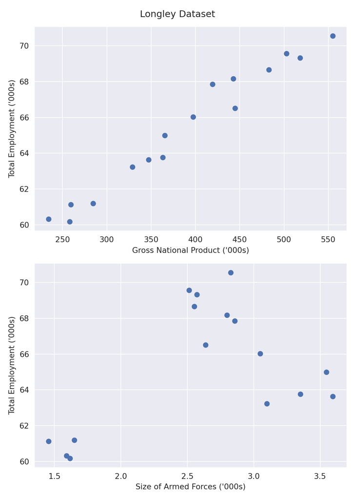

```python
# Plot
sns.set_style('darkgrid')
sns.set_palette('deep')
plt.figure(figsize=(6.4, 9))
plt.suptitle('Longley Dataset')
# First sub-plot
ax1 = plt.subplot(211)
ax1.scatter(X['GNP'], y)
ax1.set_ylabel("Total Employment ('000s)")
ax1.set_xlabel("Gross National Product ('000s)")
# Second sub-plot
ax2 = plt.subplot(212)
ax2.scatter(X['ARMED'], y)
ax2.set_ylabel("Total Employment ('000s)")
ax2.set_xlabel("Size of Armed Forces ('000s)")
# Finish
plt.tight_layout()
plt.show()
```

# 3 Assumptions

Any type of statistical analysis will make assumptions. Multiple linear regression makes four and we need to check that they are met:

1. **Linearity** can be assessed by plotting the predictor variables against the outcome variable and looking for linear relationships. This has been done above.
2. **Normality** can be assessed *after* the model has been fitted by plotting a histogram of its residuals. This should have an approximately normal distribution.
3. **Homoscedasticity** can also be checked for after fitting the model by plotting the residuals against the fitted values and confirming that there is no clear relationship
4. **Independence** can be assessed by confirming that the predictor variables are not linearly related to each other (this would be referred to as *multicollinearity*). Check the correlations between pairs of variables in the data: correlations close to 1 or -1 indicate that they are too closely related and that one should be removed:

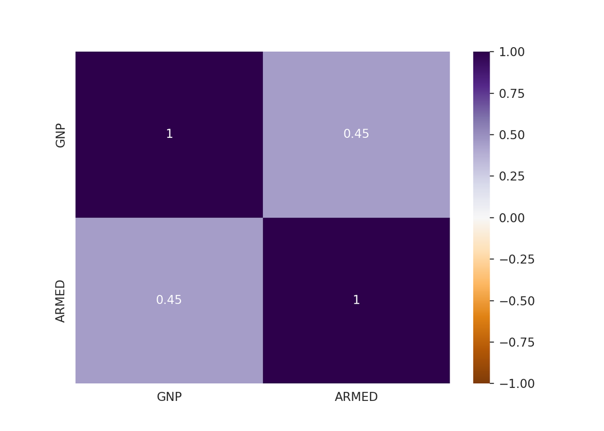

```python
# Plot a heatmap of the correlations between pairs of predictor variables
corr_grid = X.corr()
sns.heatmap(
    corr_grid, xticklabels=corr_grid.columns, yticklabels=corr_grid.columns,
    vmin=-1, center=0, vmax=1, cmap='PuOr', annot=True
)
plt.show()
```

A correlation of 0.45 between the only pair of predictor variables is sufficiently low.

# 4 Multiple Linear Regression

Start by splitting the dataset up into a training set and a testing set. Use a 70/30 split:

```python
# Split into training and testing sets
X_train, X_test, y_train, y_test = model_selection.train_test_split(
    X, y, random_state=20230922, test_size=0.3
)
```

Create and fit the model using the training set:

```python
# Create the model
regr = linear_model.LinearRegression()
# Train the model
regr.fit(X_train.values, y_train.values)
```

Get the equation of the model:

$y = m_0 x_0 + m_1 x_1 + ... + m_n x_n + c$

```python
# Get the equation
print(f'y = {regr.coef_[0]:.2f} x₀ {regr.coef_[1]:+.2f} x₁ {regr.intercept_:+.2f}')
```

```
## y = 0.04 x₀ +0.13 x₁ +51.50
```

Use the model to make a prediction: what would the employment be in a country with a GNP of 300 and a armed forces size of 3?

```python
# Use the model to make a prediction
country = [[300, 3]]
predict = regr.predict(country)

print(f'Predicted employment: {predict[0]:.2f}')
```

```
## Predicted employment: 62.42
```

Create a 3D plot to try visual the model:

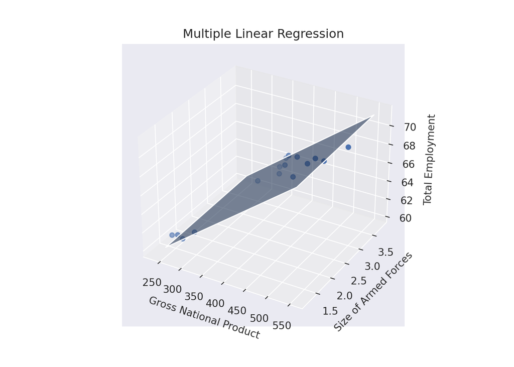

```python
# Plot
fig = plt.figure()
ax = fig.add_subplot(projection='3d')
ax.scatter(X['GNP'], X['ARMED'], y)
x_fitted = np.array([[250, 250], [550, 550]])
y_fitted = np.array([[1.2, 3.8], [1.2, 3.8]])
z_fitted = np.array([[250, 250, 550, 550], [1.2, 3.8, 1.2, 3.8]]).T
z_fitted = regr.predict(z_fitted).reshape((2, 2))
ax.plot_surface(x_fitted, y_fitted, z_fitted, alpha=0.6)
ax.set_title('Multiple Linear Regression')
ax.set_xlabel('Gross National Product')
ax.set_ylabel('Size of Armed Forces')
ax.set_zlabel('Total Employment')
plt.show()
```

# 5 Evaluate the Model

Visualise the difference between the predicted and actual values of the testing set:

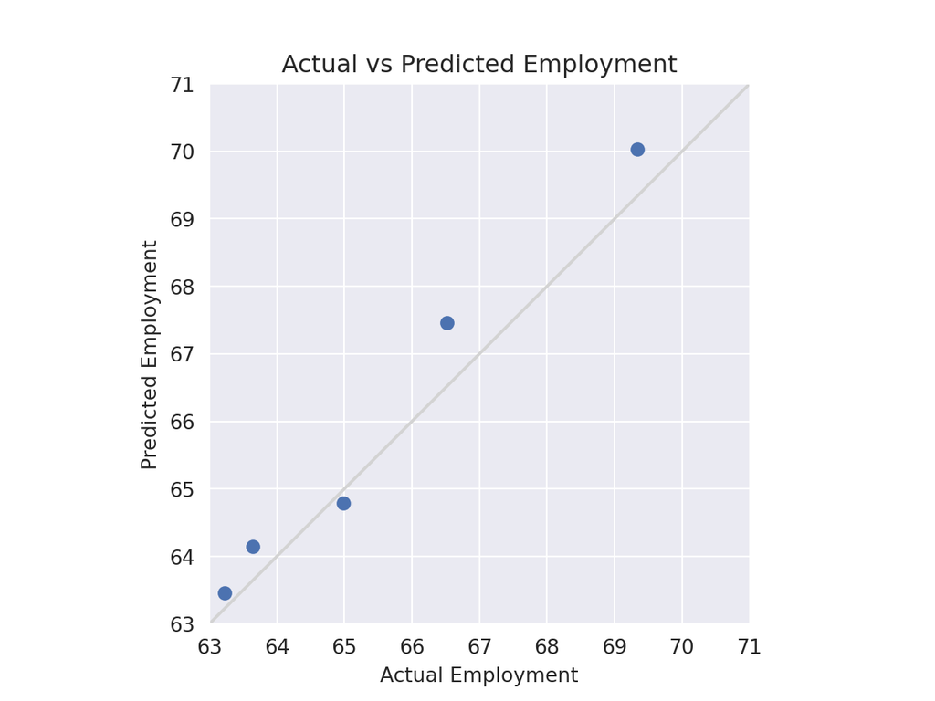

```python
# Test the model's predictions
y_pred = regr.predict(X_test.values)

# Plot
plt.figure(figsize=(6.4, 4.8))
ax = plt.axes()
ax.scatter(y_test, y_pred)
ax.plot([63, 71], [63, 71], c='lightgray')
ax.set_title('Actual vs Predicted Employment')
ax.set_ylabel('Predicted Employment')
ax.set_xlabel('Actual Employment')
ax.set_ylim(63, 71)
ax.set_xlim(63, 71)
ax.set_aspect('equal', 'box')
plt.show()
```

The coefficient of determination, $R^2$, is the proportion of the variation in $y$ that is explained by all the $x$ variables together:

```python
# Coefficient of determination, R²
u = ((y_test - y_pred) ** 2).sum()  # Residual sum of squares
v = ((y_test - y_test.mean()) ** 2).sum()  # Total sum of squares (TSS)
r_squared = 1 - (u / v)

print(f'R² = {r_squared:.3f}')
```

```
## R² = 0.930
```

Instead of calculating it manually, we can use the `.score()` method:

```python
# Coefficient of determination, R²
r_squared = regr.score(X_test.values, y_test.values)

print(f'R² = {r_squared:.3f}')
```

```
## R² = 0.930
```

In other words, 93.0% of the variation in total employment is explained by the variation in GNP and size of armed forces together.

⇦ Back